# Red Wine Exploratory Data Analysis

Stephen Chu

April 16, 2017

# Red Wine Exploratory Data Analysis by Stephen Chu

This EDA is as the title implies, about red wine. There are a number of reasons why this EDA will be interesting, but mainly because this is my first EDA using R and RStudio. And second because I have never drank red wine nor any wine at all. There will be some obvious challenges. So a forewarning to the reader: I made judicious use of online searches to help me build up a useable vocabulary and background knowledge for this topic. At several points in the EDA, I will provide direct links to my sources, but for the most part I will relegate my comments as common knowledge in the world of red wines.

This EDA was motivated by the Data Analysis course at Udacity Online. The data set is available though a research study on Red Wines by Corez et al. The following was the provided source citation for the research:

```
P. Cortez, A. Cerdeira, F. Almeida, T. Matos and J. Reis.
Modeling wine preferences by data mining from physicochemical properties.
In Decision Support Systems, Elsevier, 47(4):547-553. ISSN: 0167-9236.
```

The study is available online at: [http://www.sciencedirect.com](http://dx.doi.org/10.1016/j.dss.2009.05.016)

**Overview:** The dataset contains 1599 samples of red wine produced in the northwestern region of Portugal called Vinho Verde. The website [Vinho Verde](http://www.vinhoverde.pt/en) can help prvode some background information. The dataset has 13 variables of which only 12 will be considered for this EDA. The first variable is simply a sequential key used to denote the different entries. It will be removed. The next 11 variables contain objective measurements of physio-chemical compounds in the red wines. The final variable is a subjective quality measurement performed by a wine expert. Each quality value is taken from the median of 3 evaluations.

**Goal:** This EDA will try to determine if the physio-chemical compounds found in the Vinho Verde red wine influenced the quality assigned by the wine experts. If possible, a model may be constructed.

Before moving on to the Univariate Plots, let’s load the data set and take a quick overview.

```r
# Load in the data set.
rwData <- read.csv('wineQualityReds.csv')

# View the variable names.
names(rwData)
```

```
##  [1] "X"                    "fixed.acidity"        "volatile.acidity"
##  [4] "citric.acid"          "residual.sugar"       "chlorides"
##  [7] "free.sulfur.dioxide"  "total.sulfur.dioxide" "density"
## [10] "pH"                   "sulphates"            "alcohol"
## [13] "quality"
```

With the help of online searches, I’ll rename some of the variables to their appropriate chemical names. I’ll also completely remove the variable “X” because it only serves as a number list.

```r
# Rename some of the variable names to their actual chemical names.
rwData <- plyr::rename(rwData, c("fixed.acidity" = "tartaric.acid",
                                 "volatile.acidity" = "acetic.acid",
                                 "chlorides" = "sodium.chloride",
                                 "sulphates" = "potassium.sulphate"))

# Remove the number list column.
rwData <- subset(rwData, select = -c(X))
```

Let’s look at the structure and summary.

```r
# Display data set structure.
str(rwData)
```

```
## 'data.frame':    1599 obs. of  12 variables:
##  $ tartaric.acid       : num  7.4 7.8 7.8 11.2 7.4 7.4 7.9 7.3 7.8 7.5 ...
##  $ acetic.acid         : num  0.7 0.88 0.76 0.28 0.7 0.66 0.6 0.65 0.58 0.5 ...
##  $ citric.acid         : num  0 0 0.04 0.56 0 0 0.06 0 0.02 0.36 ...
##  $ residual.sugar      : num  1.9 2.6 2.3 1.9 1.9 1.8 1.6 1.2 2 6.1 ...
##  $ sodium.chloride     : num  0.076 0.098 0.092 0.075 0.076 0.075 0.069 0.065 0.073 0.071 ...
##  $ free.sulfur.dioxide : num  11 25 15 17 11 13 15 15 9 17 ...
##  $ total.sulfur.dioxide: num  34 67 54 60 34 40 59 21 18 102 ...
##  $ density             : num  0.998 0.997 0.997 0.998 0.998 ...
##  $ pH                  : num  3.51 3.2 3.26 3.16 3.51 3.51 3.3 3.39 3.36 3.35 ...
##  $ potassium.sulphate  : num  0.56 0.68 0.65 0.58 0.56 0.56 0.46 0.47 0.57 0.8 ...
##  $ alcohol             : num  9.4 9.8 9.8 9.8 9.4 9.4 9.4 10 9.5 10.5 ...
##  $ quality             : int  5 5 5 6 5 5 5 7 7 5 ...
```

```r
# Display data set summary.
summary(rwData)
```

```
##  tartaric.acid    acetic.acid      citric.acid    residual.sugar
##  Min.   : 4.60   Min.   :0.1200   Min.   :0.000   Min.   : 0.900
##  1st Qu.: 7.10   1st Qu.:0.3900   1st Qu.:0.090   1st Qu.: 1.900
##  Median : 7.90   Median :0.5200   Median :0.260   Median : 2.200
##  Mean   : 8.32   Mean   :0.5278   Mean   :0.271   Mean   : 2.539
##  3rd Qu.: 9.20   3rd Qu.:0.6400   3rd Qu.:0.420   3rd Qu.: 2.600
##  Max.   :15.90   Max.   :1.5800   Max.   :1.000   Max.   :15.500
##  sodium.chloride   free.sulfur.dioxide total.sulfur.dioxide
##  Min.   :0.01200   Min.   : 1.00       Min.   :  6.00
##  1st Qu.:0.07000   1st Qu.: 7.00       1st Qu.: 22.00
##  Median :0.07900   Median :14.00       Median : 38.00
##  Mean   :0.08747   Mean   :15.87       Mean   : 46.47
##  3rd Qu.:0.09000   3rd Qu.:21.00       3rd Qu.: 62.00
##  Max.   :0.61100   Max.   :72.00       Max.   :289.00
##     density             pH        potassium.sulphate    alcohol
##  Min.   :0.9901   Min.   :2.740   Min.   :0.3300     Min.   : 8.40
##  1st Qu.:0.9956   1st Qu.:3.210   1st Qu.:0.5500     1st Qu.: 9.50
##  Median :0.9968   Median :3.310   Median :0.6200     Median :10.20
##  Mean   :0.9967   Mean   :3.311   Mean   :0.6581     Mean   :10.42
##  3rd Qu.:0.9978   3rd Qu.:3.400   3rd Qu.:0.7300     3rd Qu.:11.10
##  Max.   :1.0037   Max.   :4.010   Max.   :2.0000     Max.   :14.90
##     quality
##  Min.   :3.000
##  1st Qu.:5.000
##  Median :6.000
##  Mean   :5.636
##  3rd Qu.:6.000
##  Max.   :8.000
```

The only oddity that stands out from the data set structure is the “quality” variable. It is of integer type so there is no decimal value. Perhaps later in this EDA, I may need to consider changing this variable to a factor.

The summary does show some extreme maximum values. For example, “residual.sugar” shows a maximum of 15.500 even though the minimum is 0.900 and the 3rd quantile is only 2.600. A few of the variables exhibit this behavior. They may possibly contain extreme outliers.

# Univariate Plots Section

In this section, we will look at each variable individually through univariate plots. I’ll primarily use histograms, boxplots, and barplots as neccessary. Here are the user defined functions I will be using for this section.

```r
# Custom histogram template.
do_histogram <- function(varName, binwidth = 0.05) {
  p <- ggplot(aes_string(x = varName), data = rwData) +
    geom_histogram(aes(y =..count../sum(..count..)),
                   binwidth = binwidth,
                   col = "black",
                   fill = "cyan",
                   alpha = 0.4) +
    ylab("Proportion")
  return(p)
}

# Custom boxplot template.
do_boxplot <- function(varName) {
  p <- ggplot(aes_string(x = 'varName', y = varName), data = rwData) +
    geom_boxplot(outlier.color = 'red',
                 col = "black",
                 fill = "cyan",
                 alpha = 0.4) +
    stat_boxplot(geom ='errorbar',
                 width = .5) +
    stat_summary(fun.y = mean,
                 geom ="point",
                 shape = 5,
                 size = 3) +
    theme(axis.title.x = element_blank(),
          axis.text.x = element_blank(),
          axis.ticks.x = element_blank())
  return(p)
}

# Custom barplot template.
do_barplot <- function(varName) {
  p <- ggplot(aes_string(x = varName), data = rwData) +
    geom_bar(aes(y = (..count..)/sum(..count..)),
             col = "black",
             fill = "cyan",
             alpha = 0.4) +
    ylab("Proportion")
  return(p)
}

# Function used to find lower and upper boundaries for outliers.
# Based on:
#     Lower Bound = 1st Qu. - 1.5 x IQR
#     Upper Bound = 3rd Qu. + 1.5 * IQR
lu_bounds <- function(varName, transform_type = "none") {
  switch(transform_type,
         # Default no transformation.
         none = {data <- rwData[, varName]},
         # Sqrt transform.
         sqrt = {data <- sqrt(rwData[, varName])},
         # Log10 transform.
         log10 = {data <- log10(rwData[, varName])})
  # stats[c(1, 5)] find the lower and upper values.
  lower_upper_values <- boxplot.stats(data)$stats[c(1, 5)]
  return(lower_upper_values)
}
```

### Tartaric Acid

Tartaric acid is the primary acid in red wine and contributes to the acidic flavor profile. It also has antimicrobial properties. According to [Calwineries](http://www.calwineries.com/learn/wine-chemistry/wine-acids/tartaric-acid), the amount of tartaric acid decreases with the time the grapes are “allowed to hang on the vine and mature.”

Let’s start by looking at the histogram for tartaric acid in the Vinho Verde red wine samples.

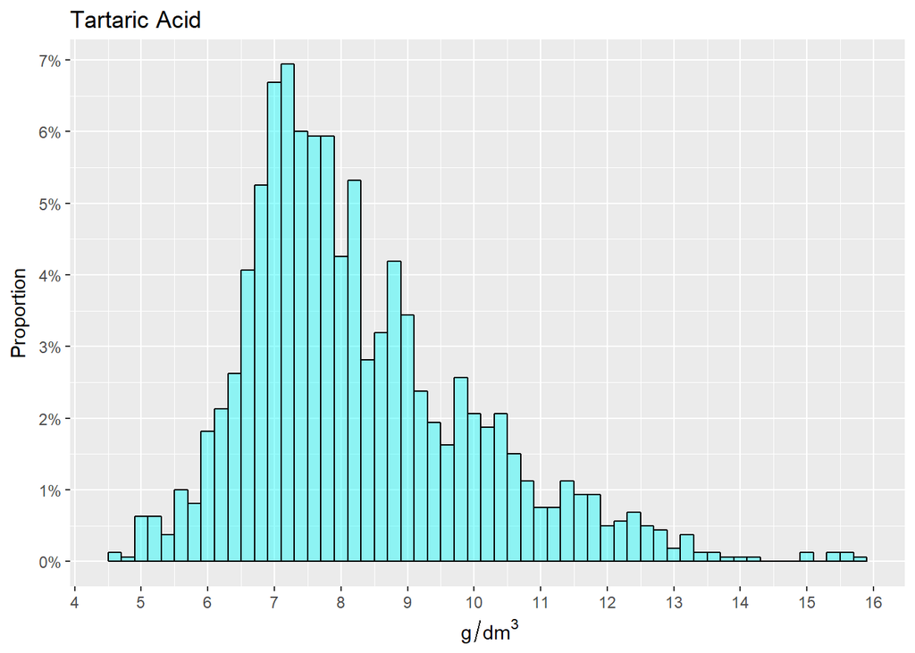

```r
# Tartaric acid histogram.
do_histogram("tartaric.acid", .2) +
  ggtitle("Tartaric Acid") +
  scale_x_continuous(~ g/dm^3, breaks = seq(4, 16, 1)) +
  scale_y_continuous(labels = percent,
                     breaks = seq(0, .1, .01))
```

Visually we can see that the majority of the distribution lay between 7 to 9 g/dm<sup>3</sup>, and there are a few outliers in the upper 15+ g/dm<sup>3</sup> area. The positive skew makes sense if the intentions were to harvest all the grapes near the time without letting the grapes lose all their tartness.

If this variable were to be used later on in a multiple regression or perhaps another analysis, a log<sub>10</sub> transform may be necessary to adjust the distribution more toward normal.

### Acetic Acid

Acetic acid is commonly known as vinegar. Though I personally do not partake in wine, I can guess that lower amounts is better for the overall wine experience. So generally, less acetic acid is better. Let’s take a look at the distribution. According to [Waterhouse Lab](http://waterhouse.ucdavis.edu/whats-in-wine/volatile-acidity), acetic acid “is a byproduct of microbial metabolism.”

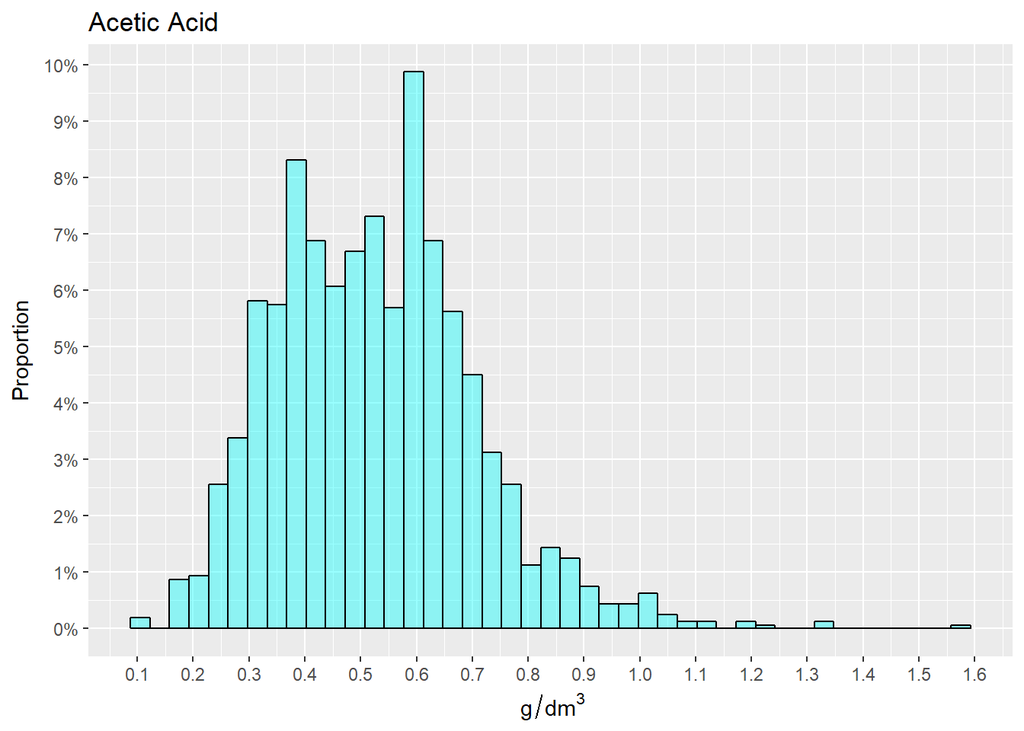

```r
# Acetic acid histogram.
do_histogram("acetic.acid", .035)  +
  ggtitle("Acetic Acid") +
  scale_x_continuous(~ g/dm^3,
                     breaks = seq(.1, 1.6, .1)) +
  scale_y_continuous(labels = percent,
                     breaks = seq(0, .1, .01))
```

The shape of the distribution has a slight positive skew like tartaric acid. There is an outlier way out over around 1.6 g/dm<sup>3</sup>. The top of the curve does not come to the characteristic point as expected. It hints at the possibility of being bimodal, but without deeper understanding of the red wine making process, it’s too difficult for me to guess why and how.

And like the tartaric acid before this, a log<sub>10</sub> transform may be neccessary before using this variable in a regression.

### Citric Acid

In the text file that accompanied this data set, citric acid is “found in small quantities,” and “can add ‘freshness’ and flavor to wines.” According to [Calwineries](http://www.calwineries.com/learn/wine-chemistry/wine-acids/citric-acid), the majority of the citric acid is “consumed by the bacterias during fermentation. The absence of citric acid would bring the fermentation process to a grinding halt, this almost never happens.”

Because citric acid has very few unique entries:

```r
# Find number of unique entries in citric acid.
length(unique(rwData$citric.acid))
```

```
## [1] 80
```

I chose to use a bar plot instead of a histogram to show the distribution.

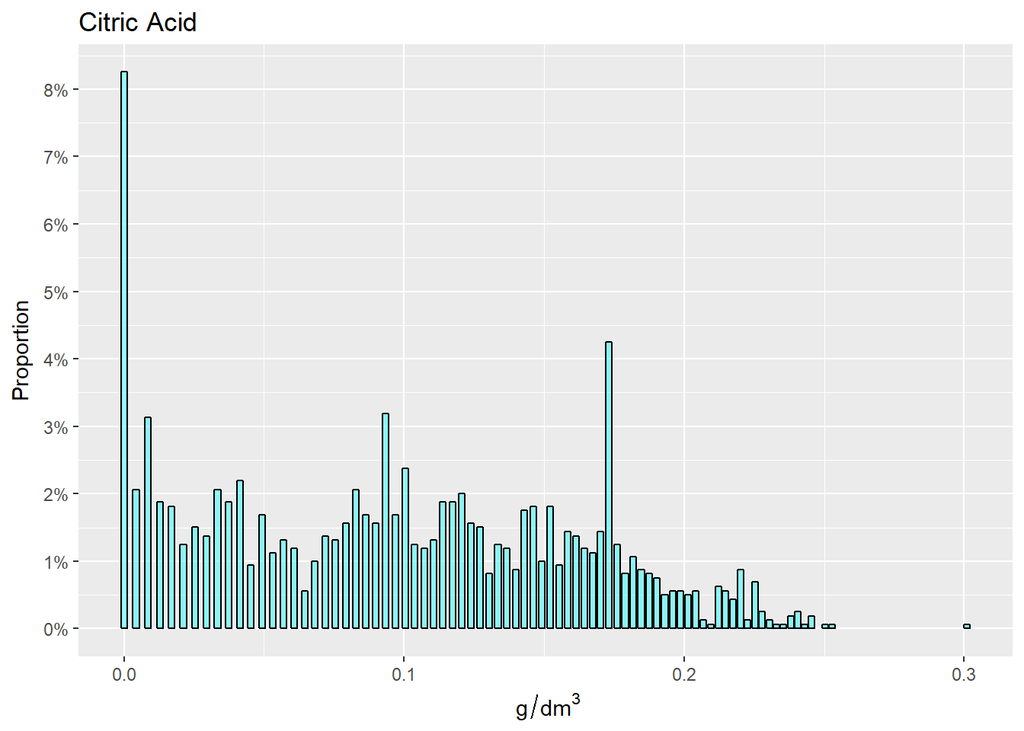

```r
# Citric acid barplot.
do_barplot("log10(citric.acid+1)") +
  ggtitle("Citric Acid") +
  scale_x_continuous(~ g/dm^3,
                     breaks = seq(0, 1, .1)) +
  scale_y_continuous(labels = percent,
                     breaks = seq(0, .08, .01))
```

### Residual Sugar

From the documentation that accompanied the data set, residual sugar is “the amount of sugar remaining after fermentation stops, it’s rare to find wines with less than 1 gram/liter and wines with greater than 45 grams/liter are considered sweet.” 1 liter is 1 dm<sup>3</sup>.

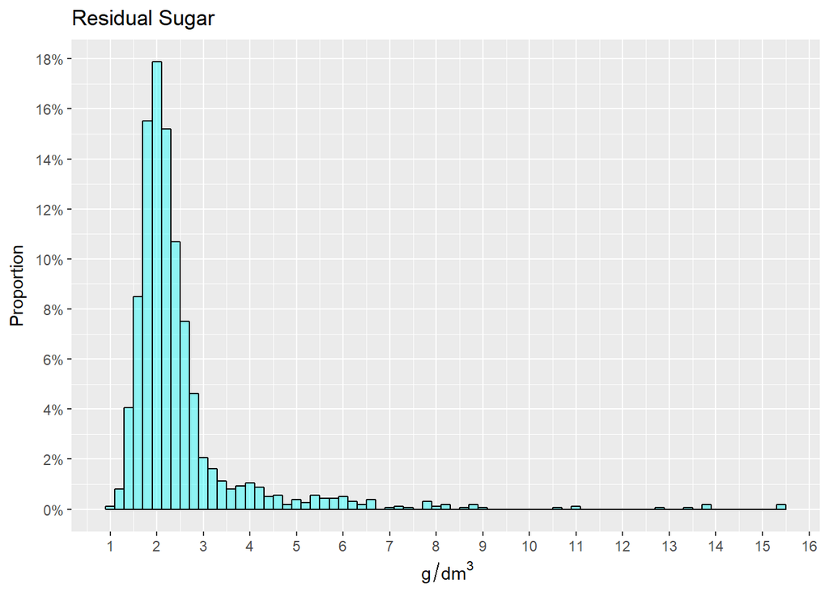

```r
# Residual sugar histogram.
do_histogram("residual.sugar", .2) +
  ggtitle("Residual Sugar") +
  scale_x_continuous(~ g/dm^3,
                     breaks = seq(0, 16, 1)) +
  scale_y_continuous(labels = percent,
                     breaks = seq(0, .18, .02))
```

I can see the vast majority of residual sugar distribution lay between 1 to 3 g/dm<sup>3</sup>. There is an extreme amount of outliers thus making this variable positively skewed. This is a very good candidate to use a log<sub>10</sub> transformation right now to better help understand the distribution.

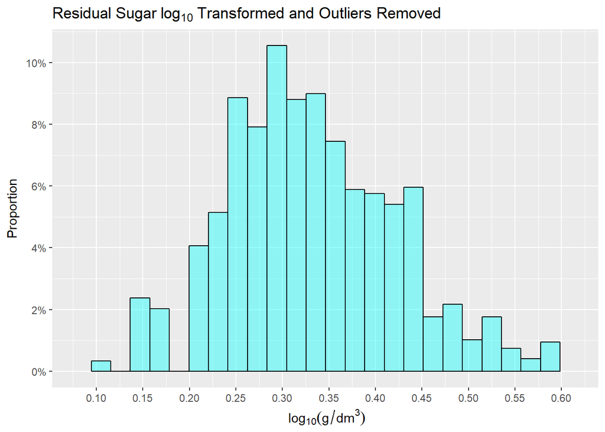

```r
# Residual sugar log10 transform and outliers removed.
do_histogram("log10(residual.sugar)", .021) +
  ggtitle("Residual Sugar"~ log[10] ~ "Transformed and Outliers Removed") +
  scale_x_continuous(~ log[10](g/dm^3),
                     limits = lu_bounds("residual.sugar", "log10"),
                     breaks = seq(0, .6, .05)) +
  scale_y_continuous(labels = percent,
                     breaks = seq(0, .18, .02))
```

After using the log<sub>10</sub> transformation as well as removing and outliers, the distribution looks better behaved. There is some striping near the lower end, but that is expected due to the original distribution.

### Sodium Chloride

Sodium chloride is commonly known as salt and it is a component in red wine. There is no readily available information for this component other than it may possibly be a product of the water used when growing the grapes. Saltiness in red wines is not considered pleasant.

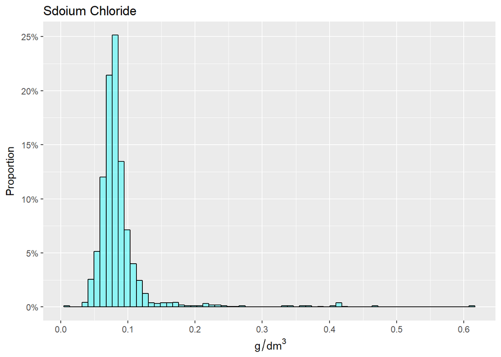

```r
# Sodium chloride histogram.
do_histogram("sodium.chloride", .009) +
  ggtitle("Sdoium Chloride") +
  scale_x_continuous(~ g/dm^3,
                     breaks = seq(0, .6, .1)) +
  scale_y_continuous(labels = percent,
                     breaks = seq(0, .25, .05))
```

The amount of salt in the distribution reflects that there is a very minute amounts of salt in red wine. The shape of the distribution has the same general characteristics as residual sugar. That is, the majority of the distribution is in a thin strip, and there is a long positive tail with outliers. I will also transform this variable right now to help visualize its distribution.

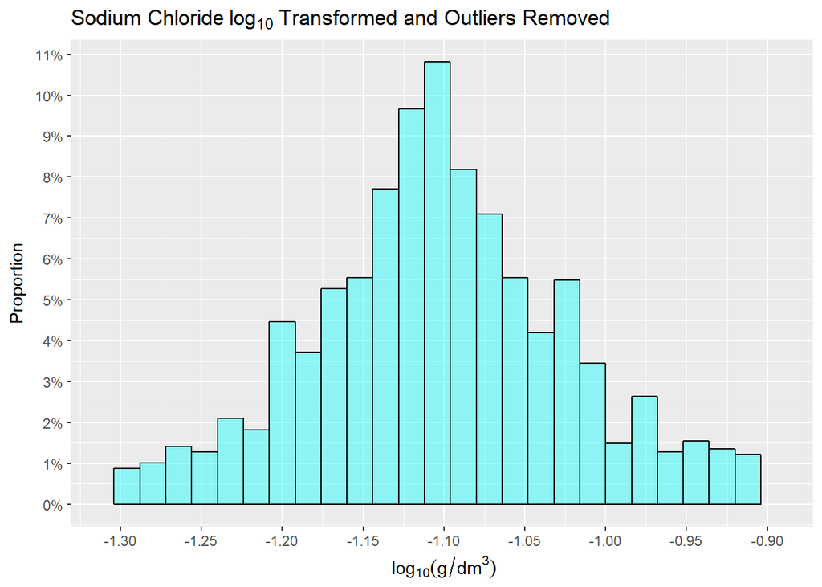

```r
# Sodium chloride log10 transform and outleirs removed.
do_histogram("log10(sodium.chloride)", .016) +
  ggtitle("Sodium Chloride" ~ log[10] ~ "Transformed and Outliers Removed") +
  scale_x_continuous(~ log[10](g/dm^3),
                     limits = lu_bounds("sodium.chloride", "log10"),
                     breaks = seq(-1.3, -0.8, .05)) +
  scale_y_continuous(labels = percent,
                     breaks = seq(0, .11, .01))
```

After the using log<sub>10</sub> and removing the outliers, the distribution looks much better.

### Free Sulfur Dioxide

**Free Sulfur Dioxide:** The accompanying documentation with the data set refers to this compound as “the free form of SO<sub>2</sub> [that] exists in equilibrium between molecular SO<sub>2</sub> (as a dissolved gas) and bisulfite ion; It prevents microbial growth and the oxidation of wine.”

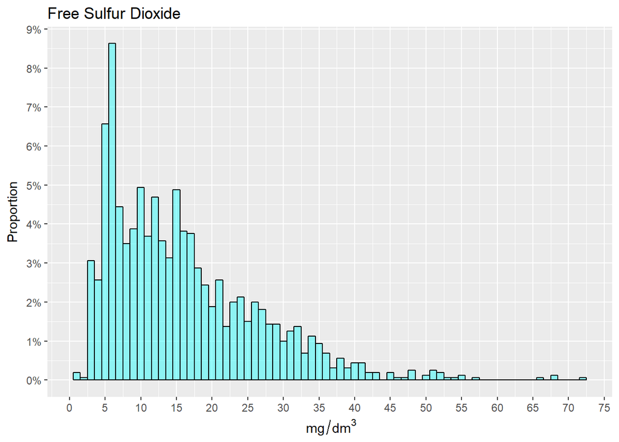

```r
# Free sulfur dioxide histogram.
do_histogram("free.sulfur.dioxide", 1) +
  ggtitle("Free Sulfur Dioxide") +
  scale_x_continuous(~ mg/dm^3,
                     breaks = seq(0, 75, 5)) +
  scale_y_continuous(labels = percent,
                     breaks = seq(0, .1, .01))
```

### Total Sulfur Dioxide

**Total Sulfur Dioxide:** “Amount of free and bound forms of S0<sub>2</sub>; In low concentrations, SO<sub>2</sub> is mostly undetectable in wine, but at free SO<sub>2</sub> concentrations over 50 ppm, SO<sub>2</sub> becomes evident in the nose and taste of wine.” In other words, this is free sulfur dioxide and the bounded form. The bounded SO<sub>2</sub> form, according to [Wine From Here](https://winobrothers.com/2011/10/11/sulfur-dioxide-so2-in-wine/), “is the part which has already done its work and cannot be useful any longer.”

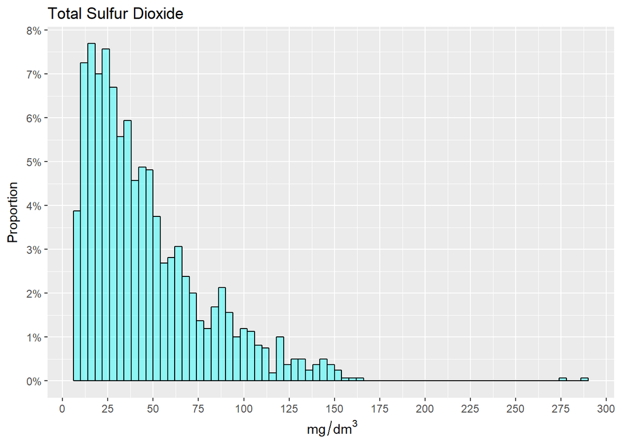

```r
# Total sulfur dioxide histogram.
do_histogram("total.sulfur.dioxide", 4) +
  ggtitle("Total Sulfur Dioxide") +
  scale_x_continuous(~ mg/dm^3,
                     breaks = seq(0, 300, 25)) +
  scale_y_continuous(labels = percent,
                     breaks = seq(0, .08, .01))
```

As we can see, this is another variable that is extremely postive skewed and has outliers at the extremes. This variable will need to be transformed as needed if used in a regression.

### Density

**Density:** The density of water is close to that of water depending on the percent alcohol and sugar content.

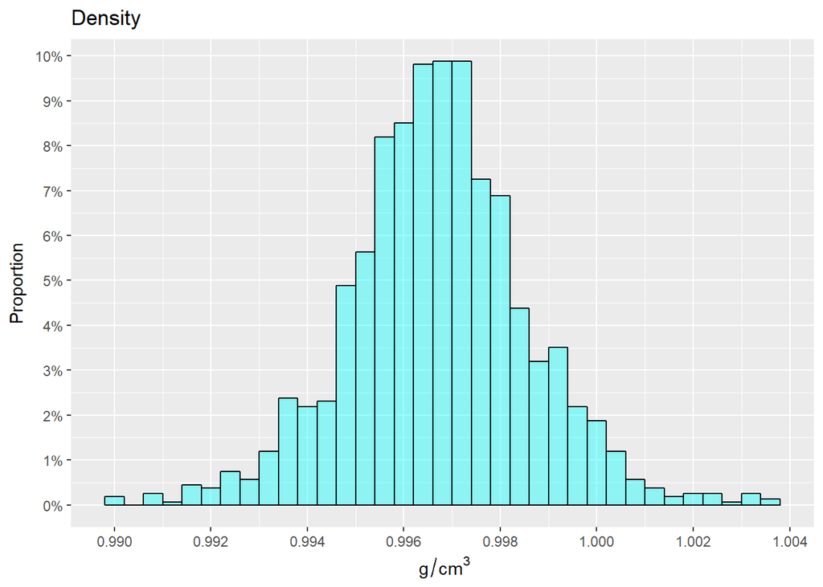

```r
# Density histogram.
do_histogram("density", .0004) +
  ggtitle("Density") +
  scale_x_continuous(~ g/cm^3,
                     breaks = seq(0.99, 1.004, .002)) +
  scale_y_continuous(labels = percent,
                     breaks = seq(0, .14, .01))
```

The distribution for density looks surprisingly normal compared to the majority of the other variables. We can clearly see that on average, the density of Vinho Verde red win is around 0.997 g/cm<sup>3</sup>, and it looks fairly balanced on both sides. There may be a need later on to check for outliers that fall outside the +/- 1.5 x IQR range.

### pH Level

**pH Level:** Describes how acidic or basic a wine is on a scale from 0 (very acidic) to 14 (very basic); most wines are between 3-4 on the pH scale.

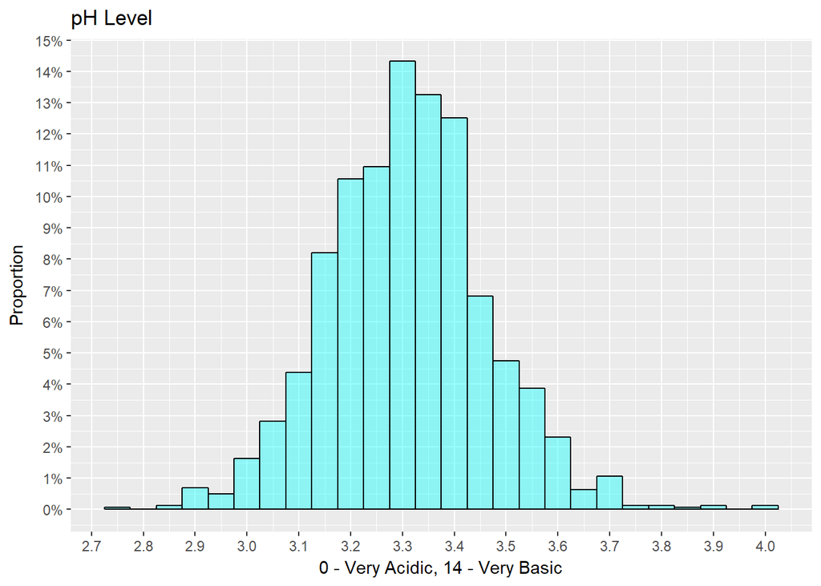

```r
# pH level histogram.
do_histogram("pH") +
  ggtitle("pH Level") +
  scale_x_continuous("0 - Very Acidic, 14 - Very Basic",
                     breaks = seq(2.7, 4, .1)) +
  scale_y_continuous(labels = percent,
                     breaks = seq(0, .15, .01))
```

The average pH level makes Vinho Verde red wines a little acidic. According to general online searches, it’s about on par with diet sodas. The shape of the distribution is also look fairly normal and there does not seem to be a need to transform the variable.

### Potassium Sulphate

**Potassium Sulphate:** A wine additive which can contribute to sulfur dioxide gas (S0<sub>2</sub>) levels, which acts as an antimicrobial and antioxidant.

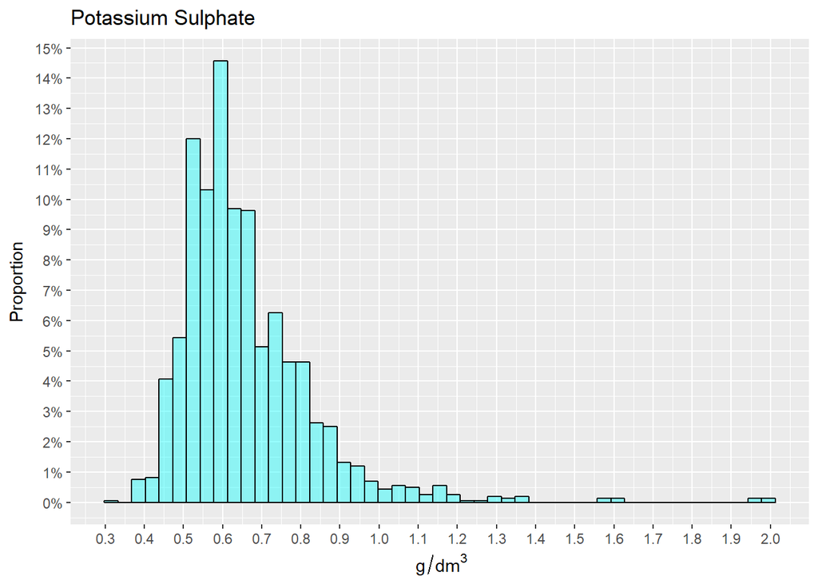

```r
# Potassium sulphate histogram.
do_histogram("potassium.sulphate", .035) +
  ggtitle("Potassium Sulphate") +
  scale_x_continuous(~ g/dm^3,
                     breaks = seq(.3, 2, .1)) +
  scale_y_continuous(labels = percent,
                     breaks = seq(0, .15, .01))
```

Potassium sulphate generally has the same distribution as salt and sugar. It is positively skewed and has extreme outliers. A log<sub>10</sub> transform and removal of outliers will be done now to see if it helps improve its distribution.

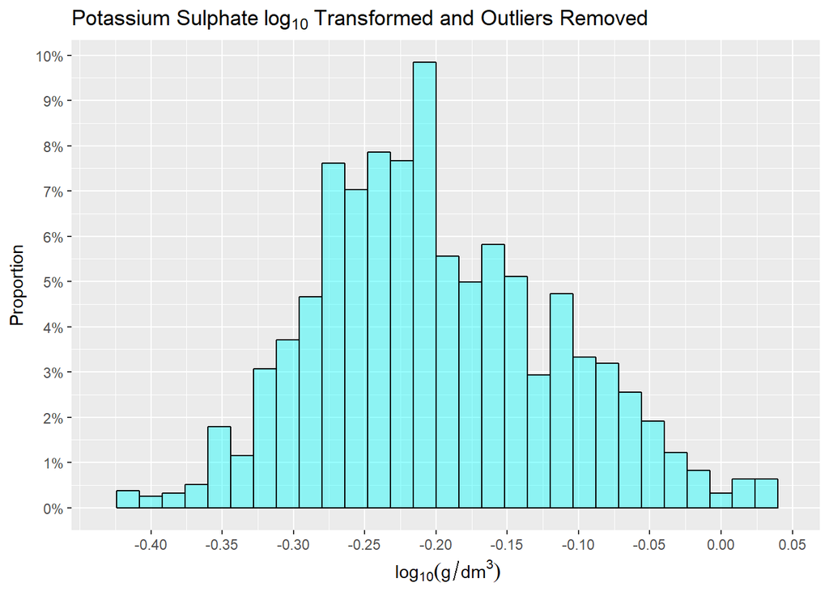

```r
# Potassium sulphate log10 transform and outliers removed.
do_histogram("log10(potassium.sulphate)", .016) +
  ggtitle("Potassium Sulphate" ~ log[10] ~ "Transformed and Outliers Removed") +
  scale_x_continuous(~ log[10](g/dm^3),
                     breaks = seq(-.4, .05, .05),
                     limits = lu_bounds("potassium.sulphate", "log10")) +
  scale_y_continuous(labels = percent,
                     breaks = seq(0, .16, .01))
```

As expected, there is a significant improvement after transformining and removing the outliers.

### Alcohol

**Alcohol:** The percent alcohol content of the wine.

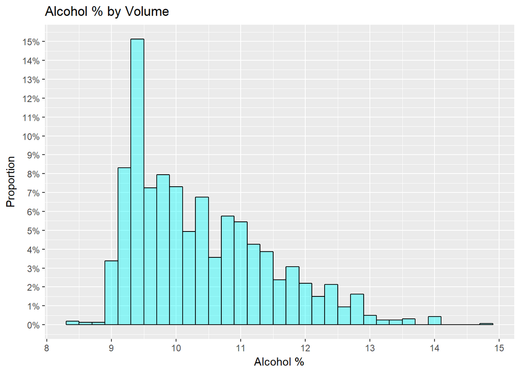

```r
# Alcohol histogram.
do_histogram("alcohol", .2) +
  ggtitle("Alcohol % by Volume") +
  scale_x_continuous("Alcohol %",
                     breaks = seq(0, 15, 1)) +
  scale_y_continuous(labels = percent,
                     breaks = seq(0, .16, .01))
```

The alcohol variable has an obvious postive skew with a few obvious outlers. Unfortunately, a suitable transformation was not found that could improve the skew.

### Wine Quality

**Wine Quality:** Output variable (based on sensory data): QUALITY (score between 0 and 10)

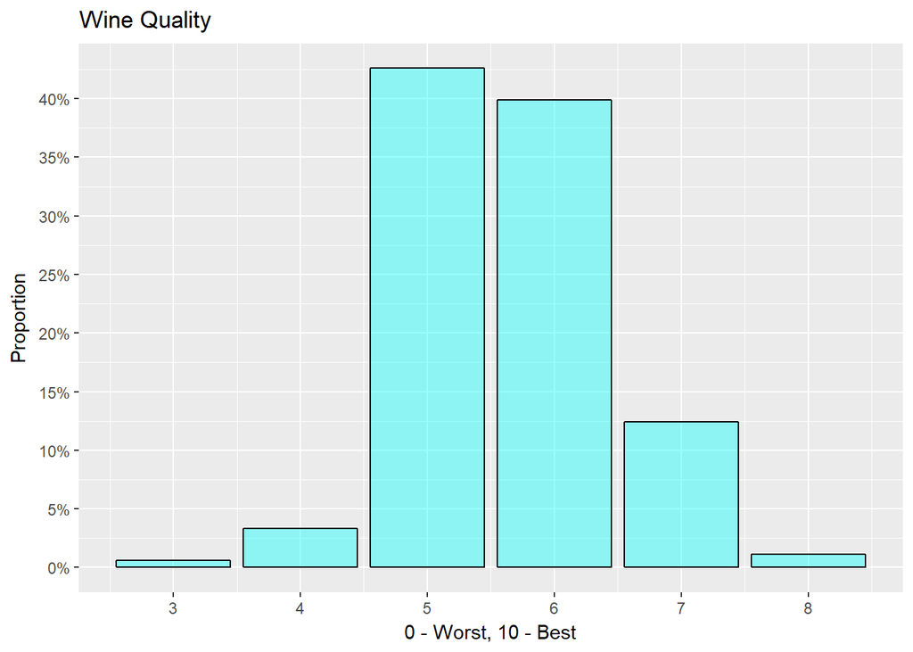

```r
# Wine quality barplot.
do_barplot("quality") +
  ggtitle("Wine Quality") +
  scale_x_continuous("0 - Worst, 10 - Best", breaks = seq(0, 10, 1)) +
  scale_y_continuous(labels = percent,
                     breaks = seq(0, .45, .05))
```

This variable is the response variable in the data set and it is the main feature of interest. The shape of the bar plot does not look normal, but because the values are discrete values from 3 to 8, it is not completely surprising. We can see the majority of the assigned values are either 5 or 6. So the wine tasters on average gave quality scores of 5 or 6. It would be interesting to find out later what characterisitcs differentiates a 3 from an 8.

# Univariate Analysis

### What is/are the main feature(s) of interest in your dataset?

As stated above, the primary feature of interest is the wine quality.

### What other features in the dataset do you think will help support your investigation into your feature(s) of interest?

I think at this point, most of the variables could support investigating the wine quality variable. The only questionable variable would be citric acid, but that’s only because I could not immediately determine a way to reasonably normalize it. This means that it may be difficult to create a regression model using citric acid.

### Did you create any new variables from existing variables in the dataset?

No new variables were created.

### Of the features you investigated, were there any unusual distributions? Did you perform any operations on the data to tidy, adjust, or change the form of the data? If so, why did you do this?

Most of the variables had visibile issues with normality and some needed a transformation to make them look more normal, but it’s not perfect. This leads to an issue on how to proceed with analysis that requires normalized variables. In the strictest sense, if a variable fails a normality test (ie qq-plot, Shapiro-Wilks, etc), then any analysis that uses said variable is meaningless.

Knowing this, I would assert that information can still be gained from doing bivariate and multivariate plots. Perhaps by doing so, it may help determine a direction for doing a regression or how to proceed using problem variables.

# Bivariate Plots Section

There are many possible bivariate plots that can be done with the 12 variables. Instead of doing every single possible combination, I’ll start with a Spearman method correlation matrix to help narrow our focus. The Spearman method is appropriate for this instance because it is non-parametric and thus does not require variable normality and it is robust to outliers. I am strictly using this matrix as a guide.

## Spearman Correlation Matrix

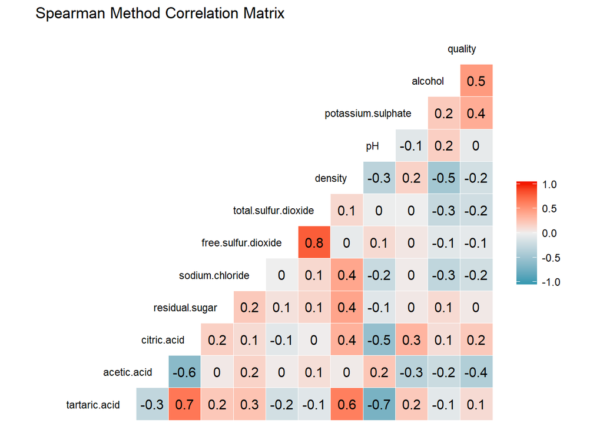

```r
# Spearman Correlation Matrix.
ggcorr(rwData, label = TRUE, hjust = 1, size = 3, layout.exp = 2,
       method = c("pairwise", "spearman")) +
  ggtitle("Spearman Method Correlation Matrix")
```

What immediately stands out from the matrix are the following correlations:

**Very Strong Correlation (.8 to 1):**

- Total Sulfur Dioxide vs. Free Sulfur Dioxide

**Strong Correlation (.6 to .79):**

- Density vs Tartaric Acid
- pH Level vs Tartaric ACid
- Tartaric Acid vs. Citric Acid
- Acetic Acid vs Citric Acid

**Moderate Correlation (.4 to .59):**

- Quality vs Acetic Acid, Potassium Sulphate, and Alcohol
- Density vs Citric Acid, Residual Sugar, Sodium Chloride, and Alcohol
- pH Level vs Citric Acid

I’ll use the above list to set the order in which to investigate the bivariate plots. Before doing so, the following are the custom functions I’ll use to display the scatterplots and the boxplots.

```r
# Custom scatterplot template.
do_scatterplot <- function(varName1, varName2) {
  p <- ggplot(aes_string(x = varName1, y = varName2), data = rwData) +
    geom_jitter(alpha = .3,
                col = 'green') +
    geom_smooth(method = 'lm')
  return(p)
}

# Custom boxplot template for bivariate plots.
do_boxplot.b <- function(varName1, varName2) {
  p <- ggplot(aes_string(x = varName1, y = varName2), data = rwData) +
    geom_boxplot(outlier.color = 'red',
                 alpha = .3,
                 col = 'blue',
                 fill = 'green') +
    stat_boxplot(geom ='errorbar',
                 width = .5,
                 col = 'blue') +
    stat_summary(fun.y = mean,
                 geom ="point",
                 shape = 5,
                 size = 3)
  return(p)
}
```

## Very Strong Correlation (.8 to 1) Bivariate Plots

The first bivariate plot will be a scatterplot of free sulfur dioxide vs total sulfur dioxide. This is the only variable pairing identified by the matrix to have a very strong correlation.

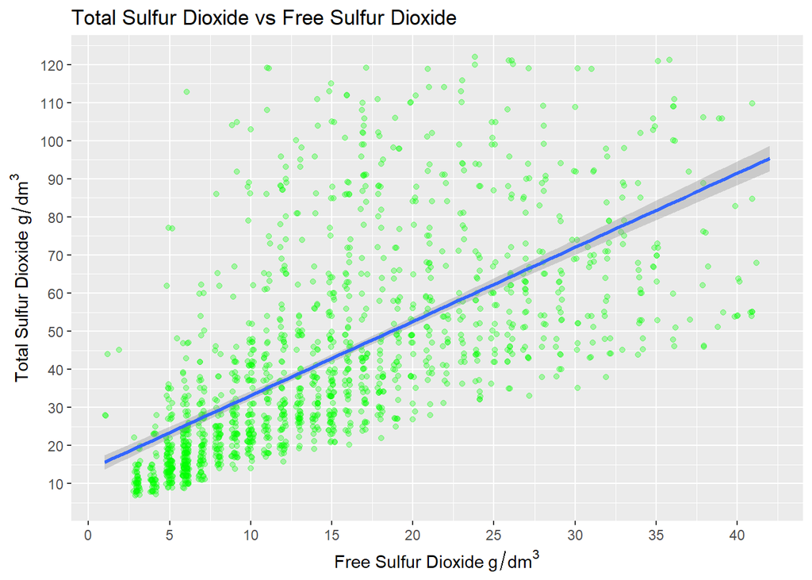

```r
# Display scatterplot of total vs free sulfur dioxide. Outliers are removed.
do_scatterplot("free.sulfur.dioxide", "total.sulfur.dioxide") +
  ggtitle("Total Sulfur Dioxide vs Free Sulfur Dioxide") +
  scale_x_continuous("Free Sulfur Dioxide" ~ g/dm^3,
                     limits = lu_bounds("free.sulfur.dioxide"),
                     breaks = seq(0, 45, 5)) +
  scale_y_continuous("Total Sulfur Dioxide" ~ g/dm^3,
                     limits = lu_bounds("total.sulfur.dioxide"),
                     breaks = seq(0, 120, 10))
```

We can see from the scatterplot that even if the line was not drawn, we could still see there is a very strong monotonic relationship. This relationship makes sense because total sulfur dioxide was described as a composite of both free sulfur dioxide (which we have data on), and bounded sulfur dioxide (no data).

In terms of drawing additional insight into the data set, there isn’t a whole lot of information in this scatterplot. Though if these variables are identified to be used in a multiple linear regression, it is now known to only select one or the other to avoid multicollinearity.

## Strong Correlation (.6 to .79) Bivariate Plots

In this section, there are 4 variable pairings to consider:

- Density vs Tartaric Acid
- pH Level vs Tartaric ACid
- Tartaric Acid vs. Citric Acid
- Acetic Acid vs Citric Acid

Let’s start at the top of the list.

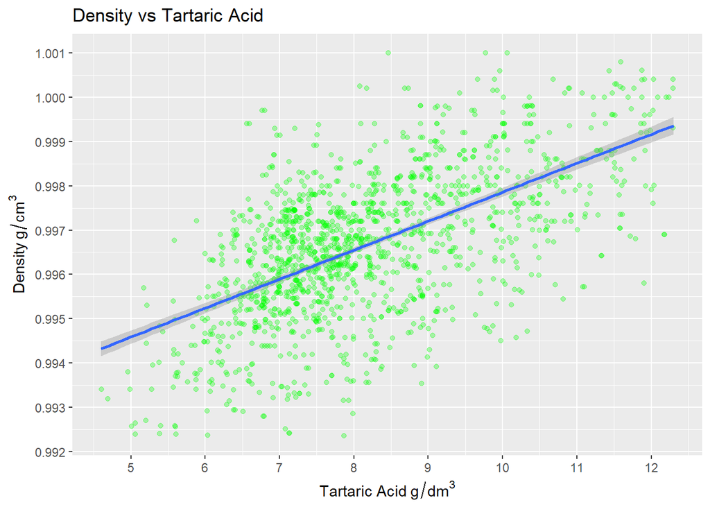

```r
# Display scatterplot of density vs tartaric acid. Outliers are removed.
do_scatterplot("tartaric.acid", "density") +
  ggtitle("Density vs Tartaric Acid") +
  scale_x_continuous("Tartaric Acid" ~ g/dm^3,
                     limits = lu_bounds("tartaric.acid"),
                     breaks = seq(5, 12, 1)) +
  scale_y_continuous("Density" ~ g/cm^3,
                     limits = lu_bounds("density"),
                     breaks = seq(0.99, 1.004, .001))
```

We can definitely see the correlation between density and tartaric acid. As tartaric acid increases in red wine, the density also increases. Unfortunately, I do not have the knowledge to explain how the two variables physically relate to one another.

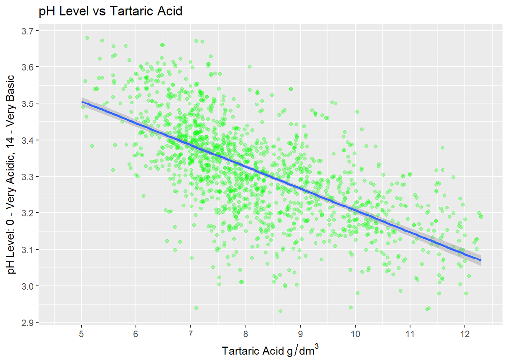

```r
# Display scatterplot of pH level vs tartaric acid. Outliers are removed.
do_scatterplot("tartaric.acid", "pH") +
  ggtitle("pH Level vs Tartaric Acid") +
  scale_x_continuous("Tartaric Acid" ~ g/dm^3,
                     limits = lu_bounds("tartaric.acid"),
                     breaks = seq(5, 12, 1)) +
  scale_y_continuous("pH Level: 0 - Very Acidic, 14 - Very Basic",
                     limits = lu_bounds("pH"),
                     breaks = seq(2.7, 4, .1))
```

The relationship between the two variables is easy to discern. As the amount of tartaric acid increases, the pH level decreases; Therefore, making the red wine more acidic. The relationship between these two variables makes sense.

**Note:** For the following plot and several others, they involve citric acid which was found in the univariate plots section to be difficult to normalize in a reasonable manner; However, that does not prevent us from making generalizations from the bivariate plots.

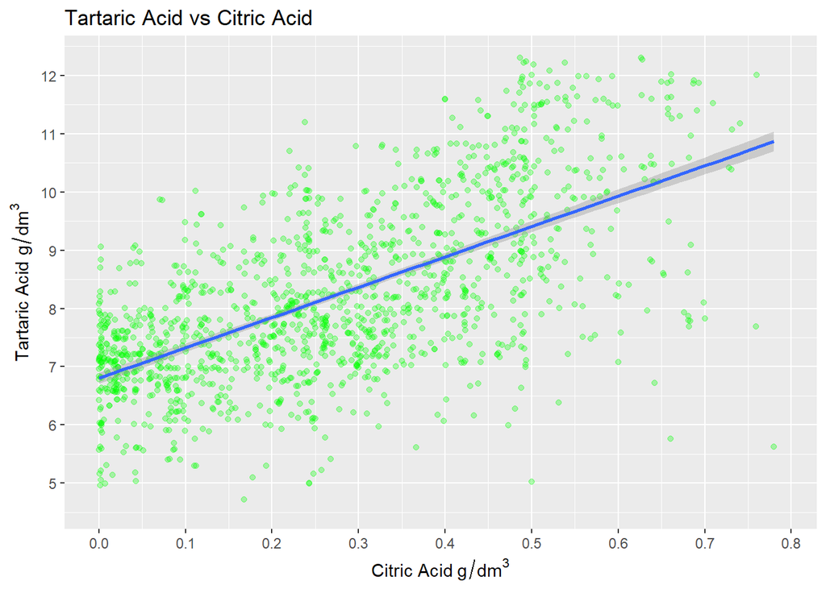

```r
# Display scatterplot of tartaric acid vs citric acid. Outliers are removed.
do_scatterplot("citric.acid", "tartaric.acid") +
  ggtitle("Tartaric Acid vs Citric Acid") +
  scale_x_continuous("Citric Acid" ~ g/dm^3,
                     limits = lu_bounds("citric.acid"),
                     breaks = seq(0, .8, .1)) +
  scale_y_continuous("Tartaric Acid" ~ g/dm^3,
                     limits = lu_bounds("tartaric.acid"),
                     breaks = seq(5, 12, 1))
```

Here we see that tartaric acid and citric acid both increase and decrease together. This relationship suggests that grapes that were harvested earlier (and thus would have higher tartaric acid) were fermented for a shorter period of time. It is unknown at the moment what effect it has on wine quality.

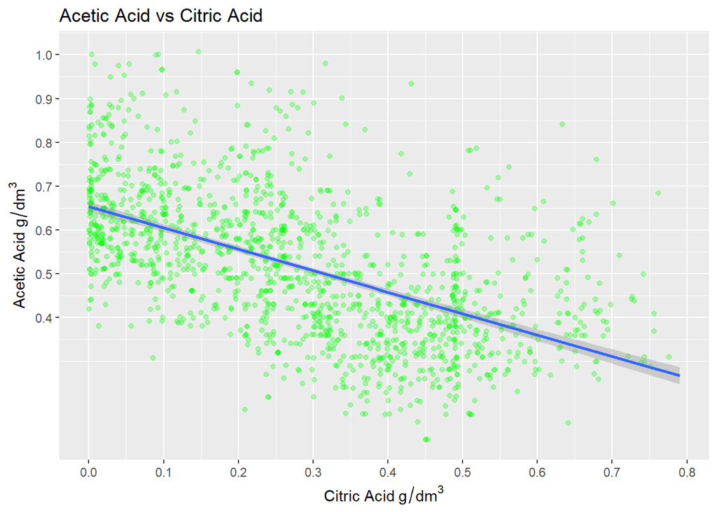

```r
# Display scatterplot of acetic acid vs citric acid. Outliers are removed.
do_scatterplot("citric.acid", "acetic.acid") +
  ggtitle("Acetic Acid vs Citric Acid") +
  scale_x_continuous("Citric Acid" ~ g/dm^3,
                     limits = lu_bounds("citric.acid"),
                     breaks = seq(0, .8, .1)) +
  scale_y_continuous("Acetic Acid" ~ g/dm^3,
                     limits = lu_bounds("acetic.acid"),
                     breaks = seq(.4, 1, .1))
```

We can see citric and acetic acid increase and decrease in opposite directions. It could be that when citric acid is in higher amounts, the wine spent less time fermenting, and thus would have less acetic acid which is a microbial byproduct of fermentation.

## Moderate Correlation (.4 to .59) Bivariate Plots

In this section, there will be 8 bivariate plots. The first three will involve the main feature of interest - wine quality. I will use boxplots due to the discrete values of the variable quality:

- Quality vs Acetic Acid, Potassium Sulphate, and Alcohol

The remaining 5 variable pairs will be done with scatterplots:

- Density vs Citric Acid, Residual Sugar, Sodium Chloride, and Alcohol
- pH Level vs Citric Acid

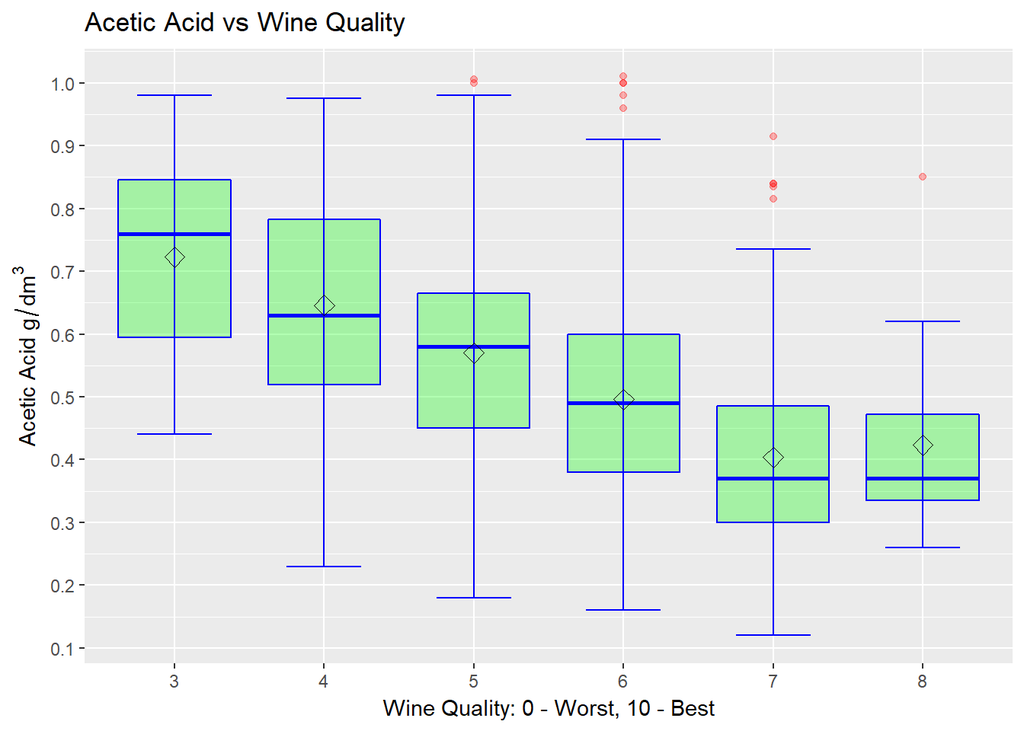

```r
# Display boxplot of acetic acid vs quality. Outliers are removed.
do_boxplot.b("factor(quality)", "acetic.acid") +
  ggtitle("Acetic Acid vs Wine Quality") +
  scale_x_discrete("Wine Quality: 0 - Worst, 10 - Best") +
  scale_y_continuous("Acetic Acid" ~ g/dm^3,
                     limits = lu_bounds("acetic.acid"),
                     breaks = seq(0, 1, .1))
```

In this first plot involving wine quality, We see that as acetic acid decreases, the assigned wine quality increases. This may not come as a suprise and it makes perfect sense because acetic acid is vinegar.

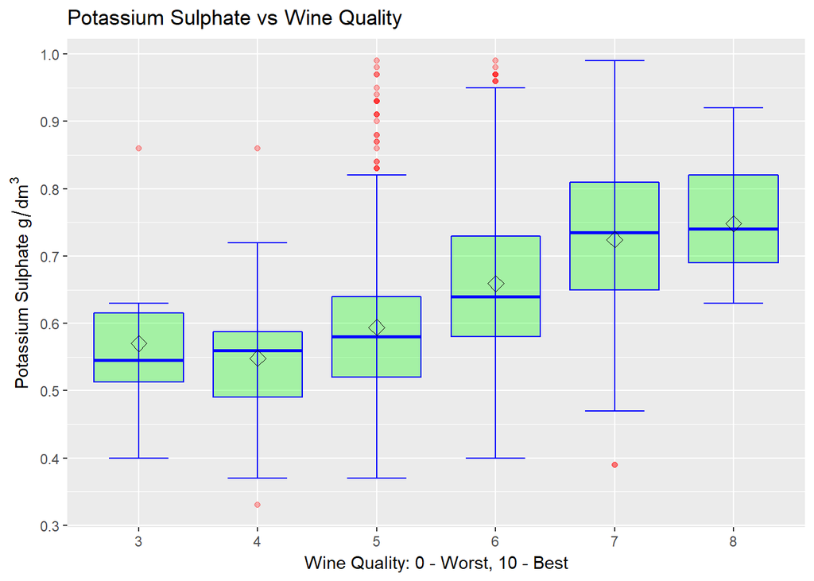

```r
# Display boxplot of potassium sulphate vs quality. Outliers are removed.
do_boxplot.b("factor(quality)", "potassium.sulphate") +
  ggtitle("Potassium Sulphate vs Wine Quality") +
  scale_x_discrete("Wine Quality: 0 - Worst, 10 - Best") +
  scale_y_continuous("Potassium Sulphate" ~ g/dm^3,
                     limits = lu_bounds("potassium.sulphate"),
                     breaks = seq(.3, 1, .1))
```

As the potassium sulphate additive is increased, wine quality also increases. The reason why may not seem clear. Potassium sulphate is described as an additive used as an antimicrobial and antioxidant. I do not have enough knowledge as to how and why this directly translates to higher wine quality other than this plot shows there is a correlation.

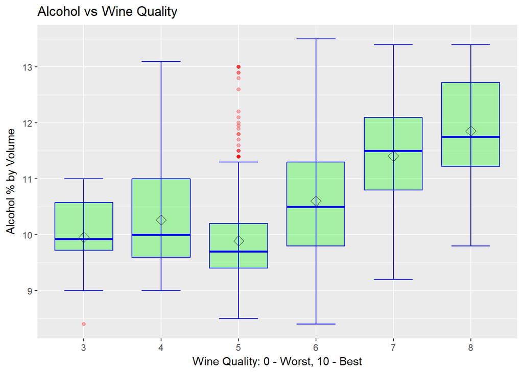

```r
# Display boxplot of alcohol vs quality. Outliers are removed.
do_boxplot.b("factor(quality)", "alcohol") +
  ggtitle("Alcohol vs Wine Quality") +
  scale_x_discrete("Wine Quality: 0 - Worst, 10 - Best") +
  scale_y_continuous("Alcohol % by Volume",
                     limits = lu_bounds("alcohol"),
                     breaks = seq(0, 15, 1))
```

In this last boxplot involving wine quality, it shows that as alcohol % increases, so does the wine quality given. An argument can be made that people enjoy alcohol in their wine. Though I do not have proof to support this, I believe it is a reasonable assumption.

The remaining moderate correlation scatterplots involve density vs 4 compounds, and pH vs citric acid. They will be shown in succession in the following order:

- Density vs Citric Acid, Residual Sugar, Sodium Chloride, and Alcohol

And the last one:

- pH Level vs Citric Acid

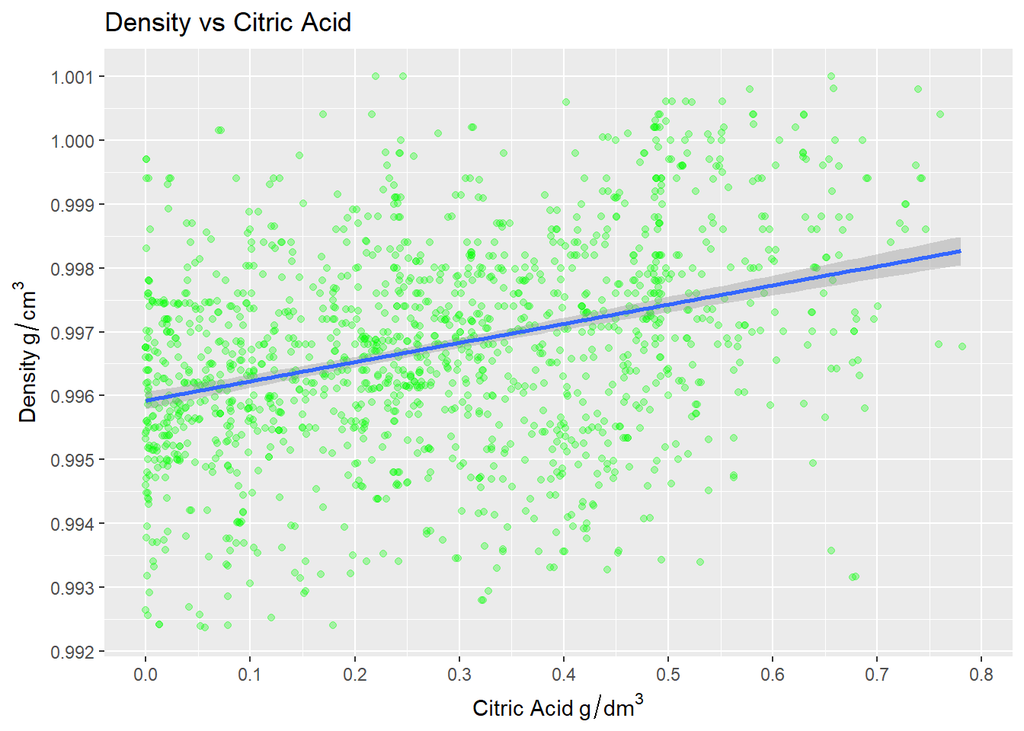

```r
# Display scatterplot of density vs citric acid. Outliers are removed.
do_scatterplot("citric.acid", "density") +
  ggtitle("Density vs Citric Acid") +
  scale_x_continuous("Citric Acid" ~ g/dm^3,
                     limits = lu_bounds("citric.acid"),
                     breaks = seq(0, .8, .1)) +
  scale_y_continuous("Density" ~ g/cm^3,
                     limits = lu_bounds("density"),
                     breaks = seq(0.99, 1.004, .001))
```

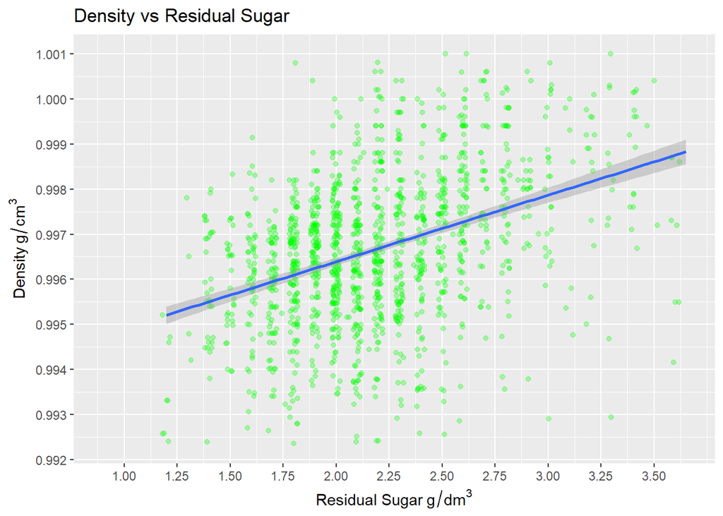

```r
# Display scatterplot of density vs residual sugar. Outliers are removed.
do_scatterplot("residual.sugar", "density") +
  ggtitle("Density vs Residual Sugar") +
  scale_x_continuous("Residual Sugar" ~ g/dm^3,
                     limits = lu_bounds("residual.sugar"),
                     breaks = seq(1, 3.5, .25)) +
  scale_y_continuous("Density" ~ g/cm^3,
                     limits = lu_bounds("density"),
                     breaks = seq(0.99, 1.004, .001))
```

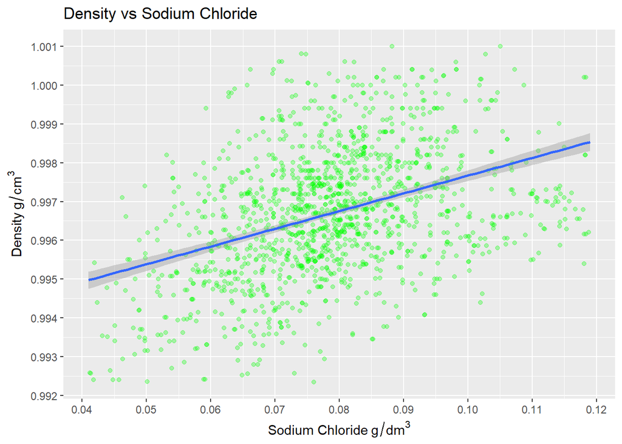

```r
# Display scatterplot of density vs sodium chloride. Outliers are removed.
do_scatterplot("sodium.chloride", "density") +
  ggtitle("Density vs Sodium Chloride") +
  scale_x_continuous("Sodium Chloride" ~ g/dm^3,
                     limits = lu_bounds("sodium.chloride"),
                     breaks = seq(.04, .12, .01)) +
  scale_y_continuous("Density" ~ g/cm^3,
                     limits = lu_bounds("density"),
                     breaks = seq(0.99, 1.004, .001))
```

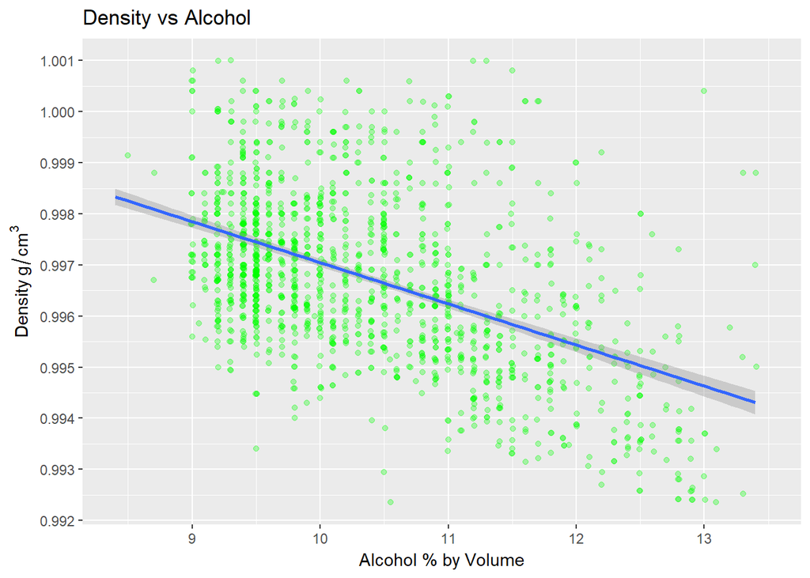

```r
# Display scatterplot of density vs alcohol. Outliers are removed.
do_scatterplot("alcohol", "density") +
  ggtitle("Density vs Alcohol") +
  scale_x_continuous("Alcohol % by Volume",
                     limits = lu_bounds("alcohol"),
                     breaks = seq(0, 15, 1)) +
  scale_y_continuous("Density" ~ g/cm^3,
                     limits = lu_bounds("density"),
                     breaks = seq(0.99, 1.004, .001))
```

For the density plots, we see that as citric acid, residual sugar, and sodium chloride increase, density increases. As the amount of alcohol increases, density decreases.

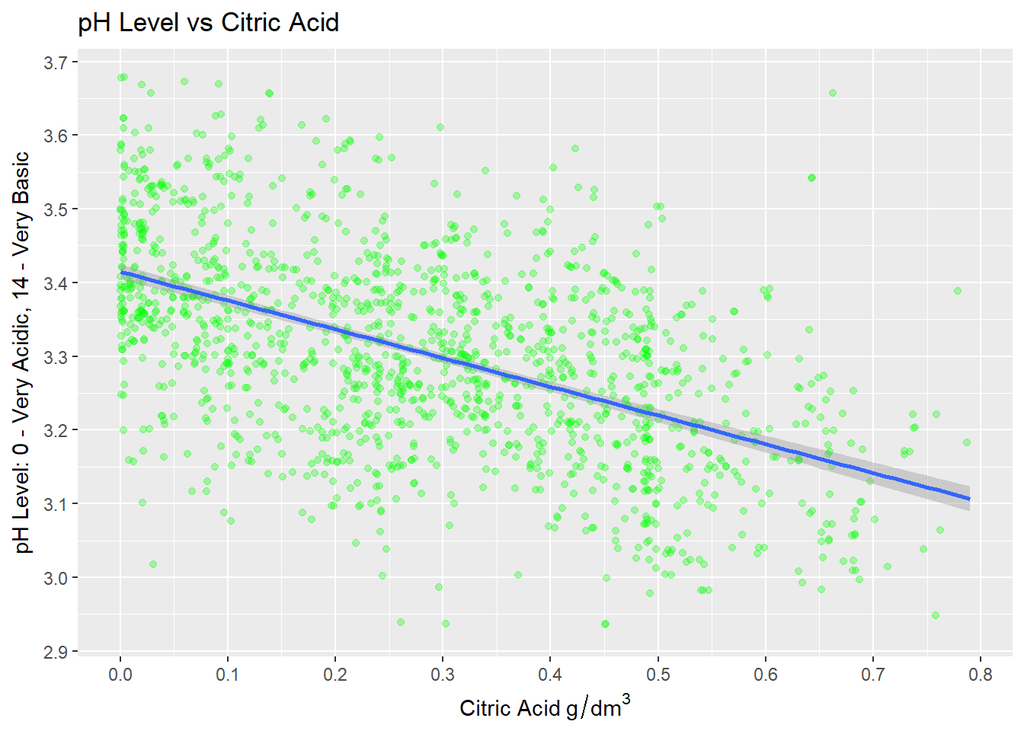

```r
# Display scatterplot of pH level vs citric acid. Outliers are removed.
do_scatterplot("citric.acid", "pH") +
  ggtitle("pH Level vs Citric Acid") +
  scale_x_continuous("Citric Acid" ~ g/dm^3,
                     limits = lu_bounds("citric.acid"),
                     breaks = seq(0, .8, .1)) +
  scale_y_continuous("pH Level: 0 - Very Acidic, 14 - Very Basic",
                     limits = lu_bounds("pH"),
                     breaks = seq(2.7, 4, .1))
```

This scatterplot should not really come as a surprise. As citric acid increases, the pH level decreases and thus the red wine is more acidic.

## Extra Plot: Very Low Correlation

Out of curiousity, I wanted to see what a very low correlation plot looks like. In the following, I chose to do a density vs acetic acid scatterplot.

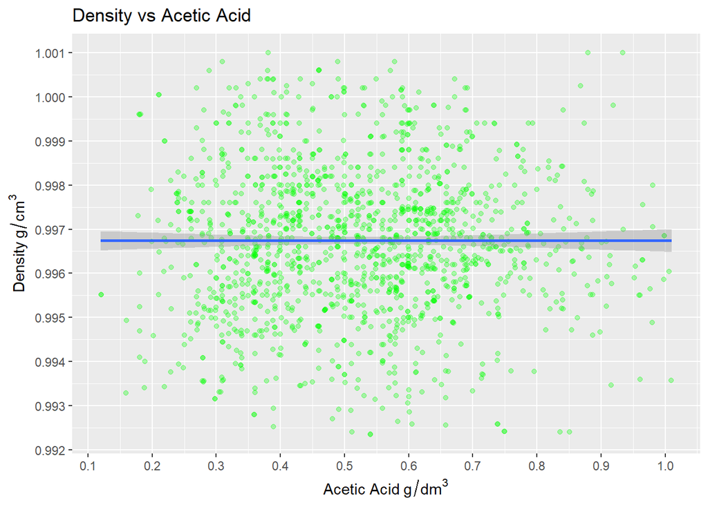

```r
# Display density vs acetic acid scatterplot.
do_scatterplot("acetic.acid", "density") +
  ggtitle("Density vs Acetic Acid") +
  scale_x_continuous("Acetic Acid" ~ g/dm^3,
                     limits = lu_bounds("acetic.acid"),
                     breaks = seq(0, 1, .1)) +
  scale_y_continuous("Density" ~ g/cm^3,
                     limits = lu_bounds("density"),
                     breaks = seq(0.99, 1.004, .001))
```

Unsurprisingly, the scatterplot looks evenly spaced out across the graph. The overlayed linear model appears to have a slope that is near zero. In other words, as the amount of acetic acid changes, the density doesn’t really change. The two variables virtually have no relation to one another.

# Bivariate Analysis

### Talk about some of the relationships you observed in this part of the investigation. How did the feature(s) of interest vary with other features in the dataset?

What was found in regards to wine quality was quite interesting. The most important I felt was that there wasn’t a very strong nor strong correlation between wine quality and any other variable. At best, there were only 3 variables that had a moderate correlation with wine quality: acetic acid, potassium sulphate, and alcohol. What this tells me is that before even making a predictive model, I can guess with certainty that the R<sup>2</sup> value would probably be around .5 or lower. The remaining variables had either low or very low correlation with wine quality.

A closer look at the plots for potassium sulphate and alcohol showed that they had a positive correlation with wine quality. The assigned wine quality, alcohol, and potassium sulphate increased and decreased together. It was difficult to determine why an increase in potassium sulphate would increase the wine quality assigned. Changes in alcohol percentages along with wine quality assigned appears to be straight forward.

On the other end, changes in acetic acid had a negative correlation with wine quality assigned. Acetic acid, as noted in the univariate section, is vinegar. It is a byproduct of fermentation that does not have a good impact on tase. So less acetic acid relates to higher wine quality.

### Did you observe any interesting relationships between the other features (not the main feature(s) of interest)?

What I found interesting was that both tartaric acid and citric acid have a negative correlation with pH level which makes sense; However, acetic acid has a very weak positive correlation. It doesn’t make sense to me because all three are acids, but only two impacted pH level in an expected manner.

Another interesting relationship were those that involved density. Out of all the density plots paired with a compound, only alcohol had a negative relationship.

The final interesting relationship is actually between the three acids. Tartaric and citric both have a positive correlation. Whereas citric acid has a strong negative correlation with acetic acid which reduces wine quality assigned. The implication is that indirectly, the presence of tartaric acid and citric acid have positive impact on wine quality. The correlation matrix does show that both tartaric and citric have a weak positive correlation to wine quality.

### What was the strongest relationship you found?

The strongest relationship found was between total sulfure dioxide and free sulfure dioxide. This is due to the fact that total sulfur dioxide is a composite of free sulfure dioxide and bounded sulfur dioxide (which is not a variable in the data set). The clearest use for this information is that when a regression is done, either total or free sulfur dioxide should be selected to avoid multicollinearity.

# Multivariate Plots Section

In the multivariate plots section, I’ll use the information from the previous portions and combine them into a more thorough plot. I’m going to focus solely on the variable of interest - wine quality. It was shown in the previous bivariate section that alcohol %, acetic acid, and potassium sulphate had moderate correlation with wine quality. For the initial plot, I decided to consider only using alcohol % and acetic acid first because those two variables are easier to explain their relation to wine quality.

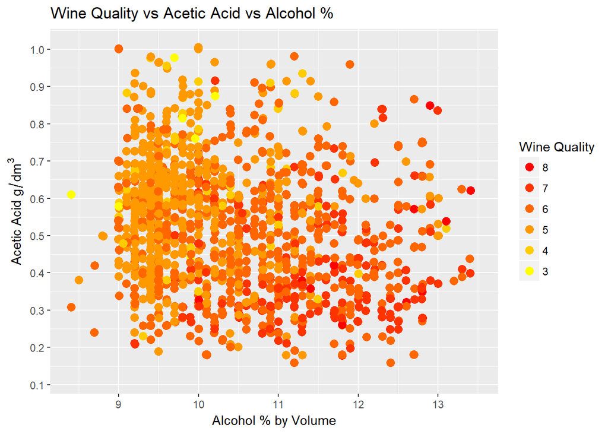

```r
# Wine Quality vs Acetic acid vs Alcohol.
ggplot(aes(x = alcohol, y = acetic.acid), data = rwData) +
  geom_jitter(aes(color = factor(quality)),
              size = 3) +
  ggtitle("Wine Quality vs Acetic Acid vs Alcohol %") +
  scale_x_continuous("Alcohol % by Volume",
                     limits = lu_bounds("alcohol"),
                     breaks = seq(0, 15, 1)) +
  scale_y_continuous("Acetic Acid" ~ g/dm^3,
                     limits = lu_bounds("acetic.acid"),
                     breaks = seq(0, 1, .1)) +
  scale_color_manual("Wine Quality",
                     values = c("#FFFF00", "#FFCC00", "#FF9900",
                                "#FF6600", "#FF3300", "#FF0000"),
                     guide = guide_legend(reverse = TRUE))
```

We can clearly see that as we go from the upper left to the lower right corner, wine quality increases (becomes redder). This shows that a reduction in acetic acid and an increase in alcohol percentage on average contribute toward a higher wine quality assessment. There is also a barely perceptible relationship between alcohol % and acetic acid amount. It looks like as alcohol % increases, acetic acid amount decreases.

Now let’s consider potassium sulphate. I’ve replaced alcohol % from the previous scatterplot with potassium sulphate. Let’s see the difference.

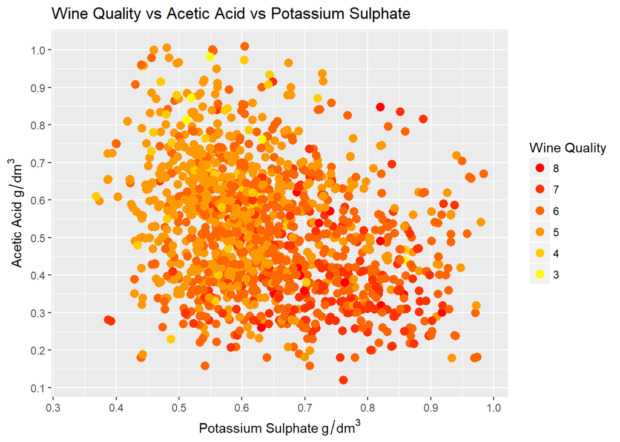

```r
ggplot(aes(x = potassium.sulphate, y = acetic.acid), data = rwData) +
  geom_jitter(aes(color = factor(quality)),
              size = 3) +
  ggtitle("Wine Quality vs Acetic Acid vs Potassium Sulphate ") +
  scale_x_continuous("Potassium Sulphate" ~ g/dm^3,
                     limits = lu_bounds("potassium.sulphate"),
                     breaks = seq(.3, 1, .1)) +
  scale_y_continuous("Acetic Acid" ~ g/dm^3,
                     limits = lu_bounds("acetic.acid"),
                     breaks = seq(0, 1, .1)) +
  scale_color_manual("Wine Quality",
                     values = c("#FFFF00", "#FFCC00", "#FF9900",
                                "#FF6600", "#FF3300", "#FF0000"),
                     guide = guide_legend(reverse = TRUE))
```

In this plot, we also see the same general trend as in the previous plot. An increase in potassium sulphate and decrease in acetic acid relate to an increase in wine quality. Between potassium sulphate and acetic acid, we can see that on average as potassium sulphate increases, acetic acid decreases. The relationship could possibly be due to potassium sulphate being used as an antimicrobial compound and acetic acid is a byproduct of microbes. So potassium sulphate coincides with a reduction of acetic acid because there are less microbes. However, this is only speculation. This doesn’t provide a better understanding of how potassium sulphate contributes to the red wine making process other than “more is better.”